# The Ride Not Taken

2024-09-01

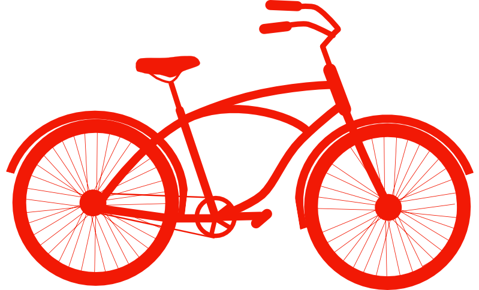

### Determining the Goal

The focus of this short project is to try my hand at forecasting seasonal data.

### Finding the Data

The city of Seattle provides an open data portal for public access. The site hosts a wide variety of data related to everything from education to public safety to city financials. For this project I selected data from the transportation section.

The Fremont Bridge is one of Seattle’s iconic bridges and also a major thoroughfare for a bike path towards the business districts of South Lake Union and Downtown. The city has tracked the number of bicycles that travel over the bridge in both directions since 2012. The data can be downloaded [here](https://data.seattle.gov/Transportation/Fremont-Bridge-Bicycle-Counter/65db-xm6k/about_data).

### Preparing the Data

```r
#load libraries
library(dplyr)
library(tidyr)
library(lubridate)
library(stringr)
library(ggplot2)
library(forecast)
library(fpp3)

#load data
counter <- read.csv("Fremont_Bridge_Bicycle_Counter_20240724.csv")

#review variable names
names(counter)
```

```
## [1] "Date"
## [2] "Fremont.Bridge.Sidewalks..south.of.N.34th.St"
## [3] "Fremont.Bridge.Sidewalks..south.of.N.34th.St.Cyclist.West.Sidewalk"
## [4] "Fremont.Bridge.Sidewalks..south.of.N.34th.St.Cyclist.East.Sidewalk"
```

```r
#rename columns
names(counter) <- c("Date_o", "Total", "West", "East")

#review data
head(counter, 10)
```

```
##                    Date_o Total West East
## 1  10/02/2012 01:00:00 PM    55    7   48
## 2  10/02/2012 02:00:00 PM   130   55   75
## 3  10/02/2012 03:00:00 PM   152   81   71
## 4  10/02/2012 04:00:00 PM   278  167  111
## 5  10/02/2012 05:00:00 PM   563  393  170
## 6  10/02/2012 06:00:00 PM   381  236  145
## 7  10/02/2012 07:00:00 PM   175  104   71
## 8  10/02/2012 08:00:00 PM    86   51   35
## 9  10/02/2012 09:00:00 PM    63   35   28
## 10 10/02/2012 10:00:00 PM    42   27   15
```

```r
#view count of missing Total field
counter %>% filter(is.na(Total)) %>% count()
```

```
##    n
## 1 28
```

```r
#replace the small number of missing counts with average Total for the whole dataset
#note: more complex imputation methods could be employed, but I am choosing to keep it simple given the small number of missing data and the overall focus of this project.
counter$Total[is.na(counter$Total)] <- mean(counter$Total, na.rm = T)

#format the date variable
counter$Date_f <- mdy_hms(counter$Date_o)

#separate out date variable into year, month, day of the week, and hour variables
counter$Year <- year(counter$Date_f)
counter$Month <- month(counter$Date_f)
counter$WDay <- wday(counter$Date_f)
counter$Hour <- hour(counter$Date_f)
```

### Reviewing the Trends

With the data updated, I then plotted the data in a variety of ways to get the overall feel for the type of seasonal trends that may be present in the data.

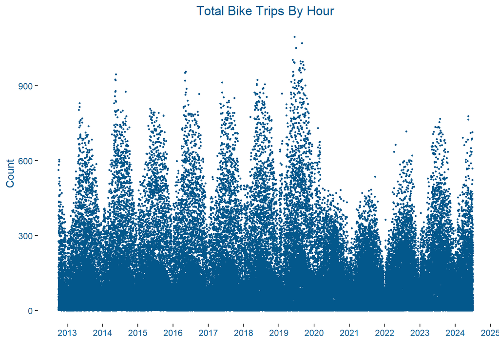

```r
#Totals over time
ggplot(counter, aes(x=Date_f, y=Total)) +
  geom_point(size =0.5, colour = "#03588C") +
  scale_x_datetime(breaks = scales::pretty_breaks(n = 20))+
  labs(title = "Total Bike Trips By Hour",
       x = "",
       y = "Count") +
  theme(plot.title = element_text(hjust = 0.5, color = "#03588C"),
        axis.title = element_text(color = "#03588C"),
        panel.grid = element_blank(),
        panel.background = element_blank(),
        axis.text = element_text(color = "#03588C"))
```

With a quick glace we can easily see that there are some seasonal effects in the data. I also noted a significant drop in counts starting in 2020. This caused me to shift my focus from my original plan of forecasting expected bike trips in the future (2024-2025) to “forecasting” what the expected bike trip counts would have been if COVID and related lock-downs did not occur.

Next I created a few plots that were a bit more simplistic to try to see how complicated the seasonality may be. I imagined the number of bike trips would vary greatly by time of day (rush hour vs middle of the night), day of the week (workday vs. weekend), and time of the year (sunny summer vs. cold and rainy winter). For each, I plotted the average totals to get an idea of the general trend.

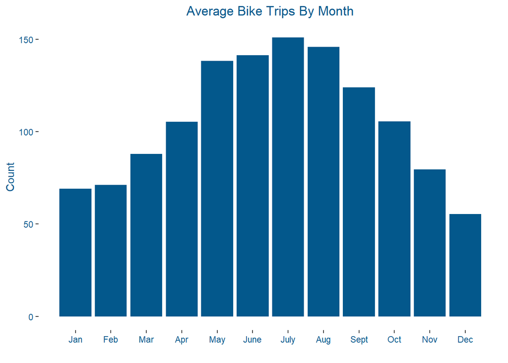

```r
#Average total by month
month_trend <- counter %>%
  group_by(Month) %>%
  summarize(Average_total = mean(Total, na.rm = T))

ggplot(month_trend, aes(x=Month, y=Average_total)) +
  geom_col(fill ="#03588C") +
  scale_x_continuous(breaks=seq(1,12,1),
        labels=c("Jan","Feb", "Mar", "Apr", "May", "June", "July", "Aug",
                 "Sept", "Oct", "Nov", "Dec")) +
  labs(title = "Average Bike Trips By Month",
       x = "",
       y = "Count") +
  theme(plot.title = element_text(hjust = 0.5, color = "#03588C"),
        axis.title = element_text(color = "#03588C"),
        panel.grid = element_blank(),
        panel.background = element_blank(),
        axis.text = element_text(color = "#03588C"))
```

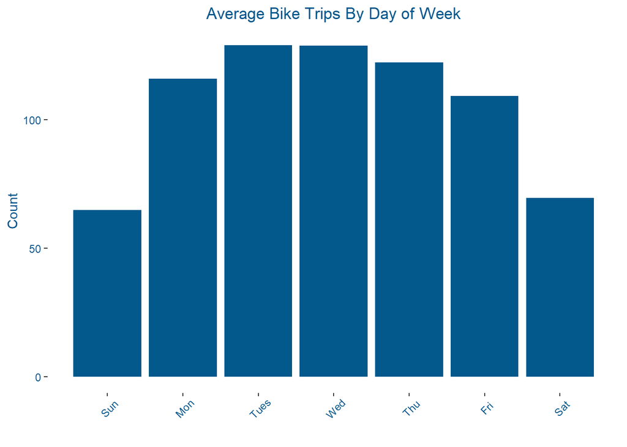

```r
#Average total by day of week
wday_trend <- counter %>%
  group_by(WDay) %>%
  summarize(Average_total = mean(Total, na.rm = T))

ggplot(wday_trend, aes(x=WDay, y=Average_total)) +
  geom_col(fill ="#03588C") +
  scale_x_continuous(breaks=seq(1,7,1),
        labels=c("Sun", "Mon", "Tues", "Wed", "Thu", "Fri", "Sat")) +
  labs(title = "Average Bike Trips By Day of Week",
       x = "",
       y = "Count") +
  theme(axis.text.x = element_text(angle = 45, vjust = 0.7),
        plot.title = element_text(hjust = 0.5, color = "#03588C"),
        axis.title = element_text(color = "#03588C"),
        panel.grid = element_blank(),
        panel.background = element_blank(),
        axis.text = element_text(color = "#03588C"))
```

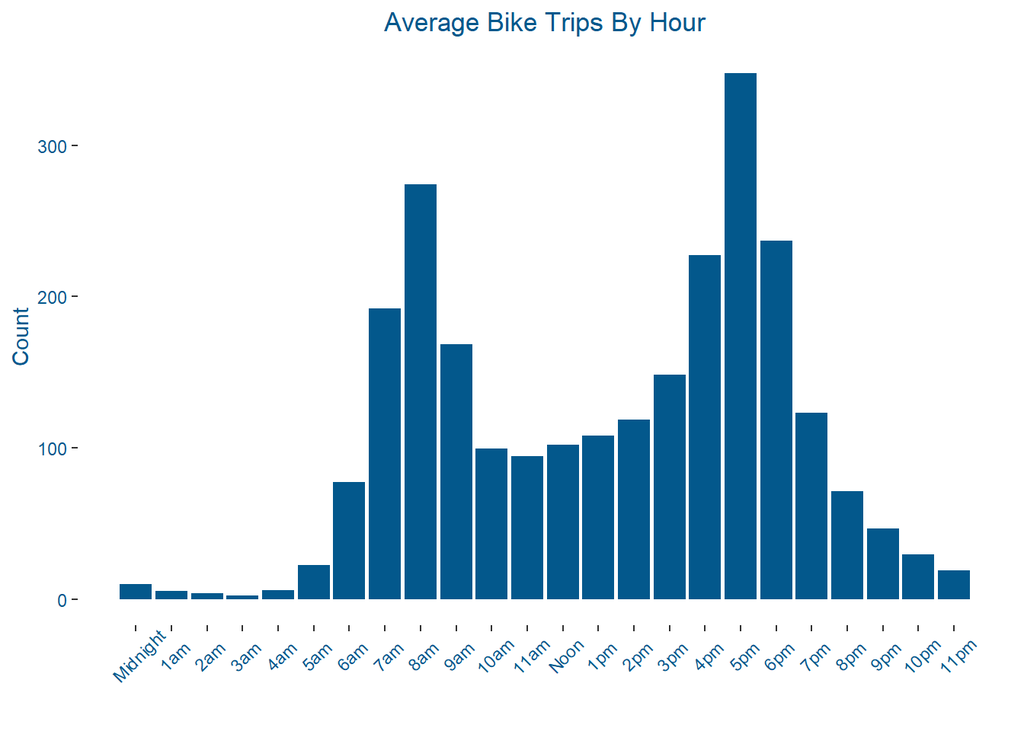

```r
#Average total by hour in the day
hour_trend <- counter %>%
  group_by(Hour) %>%
  summarize(Average_total = mean(Total, na.rm = T))

ggplot(hour_trend, aes(x=Hour, y=Average_total)) +
  geom_col(fill ="#03588C") +
  scale_x_continuous(breaks=seq(0,23,1),
                     labels=c("Midnight", "1am", "2am", "3am","4am", "5am", "6am",
                              "7am", "8am", "9am", "10am", "11am", "Noon", "1pm",
                              "2pm", "3pm", "4pm","5pm", "6pm", "7pm", "8pm",
                              "9pm","10pm","11pm")) +
  labs(title = "Average Bike Trips By Hour",
       x = "",
       y = "Count") +
  theme(axis.text.x = element_text(angle = 45, vjust = 0.7),
        plot.title = element_text(hjust = 0.5, color = "#03588C"),
        axis.title = element_text(color = "#03588C"),
        panel.grid = element_blank(),
        panel.background = element_blank(),
        axis.text = element_text(color = "#03588C"))
```

### Modeling the Pre-Pandemic Data

Governor Jay Inslee declared a state of emergency on February 29, 2020, which was followed by a statewide stay-at-home order on March 23 that would last at least two weeks. I chose the March 23rd stay-at-home order as the pre/post pandemic cutoff. While the stay-at-home order only lasted a few weeks, many Seattle employers allowed their staff to continue to work from home for months following the lockdown. Additionally, many public events were canceled or downsized during this time. This led to the lingering decreased bike counts seen in the above plot.

Given the complexity of the multiple seasonal effects, I decided to forecast using the STL() package: Seasonal Decomposition of Time Series by Loess. To prevent negative predictions, I took the log of the *Total* variable and then created the inverse log of the results.

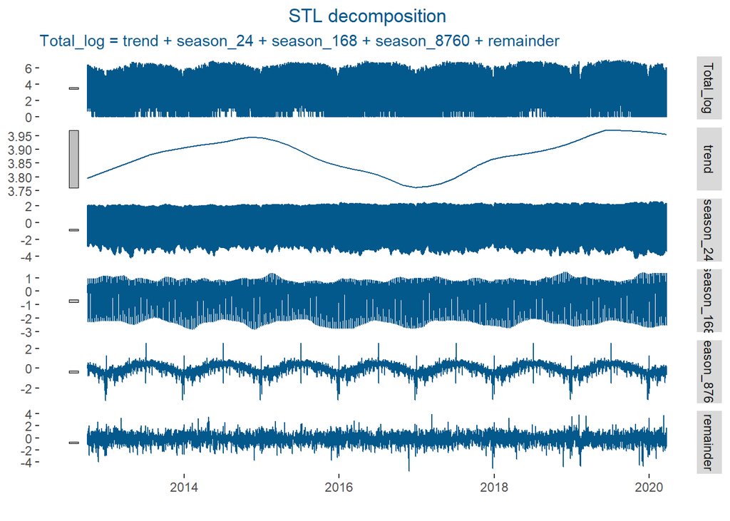

```r
#create a tsibble dataset for the model
counter_prepan <- counter %>%
  filter(Date_f < "2020-03-23") %>%
  mutate(Total_log = case_when(
    Total == 0 ~ 0,
    T~ log(Total)))  %>%
  select(Date_f, Total, Total_log) %>%
  as_tsibble(index=Date_f)

#create the post-pandemic dataset for post-model comparison
counter_postpan <- counter %>% filter(Date_f >= "2020-03-23") %>% select(Date_f, Total)

#view the trend and seasonality of the log transformed total trips variable
counter_prepan  %>%
  model(STL(Total_log ~ season(period = 24) +
                    season(period = 7*24) +
                    season(period = 365*24),
        robust = TRUE)) %>%
  components() %>%
  autoplot(color = "#03588C") +
  labs(x = "") +
  theme(plot.title = element_text(hjust = 0.5, color = "#03588C"),
        axis.title = element_text(color = "#03588C"),
        panel.grid = element_blank(),
        panel.background = element_blank(),
        text = element_text(color = "#03588C"))
```

```r
#build the model including daily, weekly, and yearly seasonality
dcmp_c_p <- decomposition_model(STL(Total_log ~ season(period = 24) +
                    season(period = 7*24) +
                    season(period = 365*24),
                    robust = TRUE),
                    ETS(season_adjust ~ season("N")))

#run the model and forecast out the number of rows available in the post-pandemic cutoff time period
fcst <- counter_prepan |>
  model(dcmp_c_p) |>
  forecast(h = 37457)

#check that the end of the forecasted data is the same end point as the observed data
max(fcst$Date_f) == max(counter_postpan$Date_f)
```

```
## [1] TRUE
```

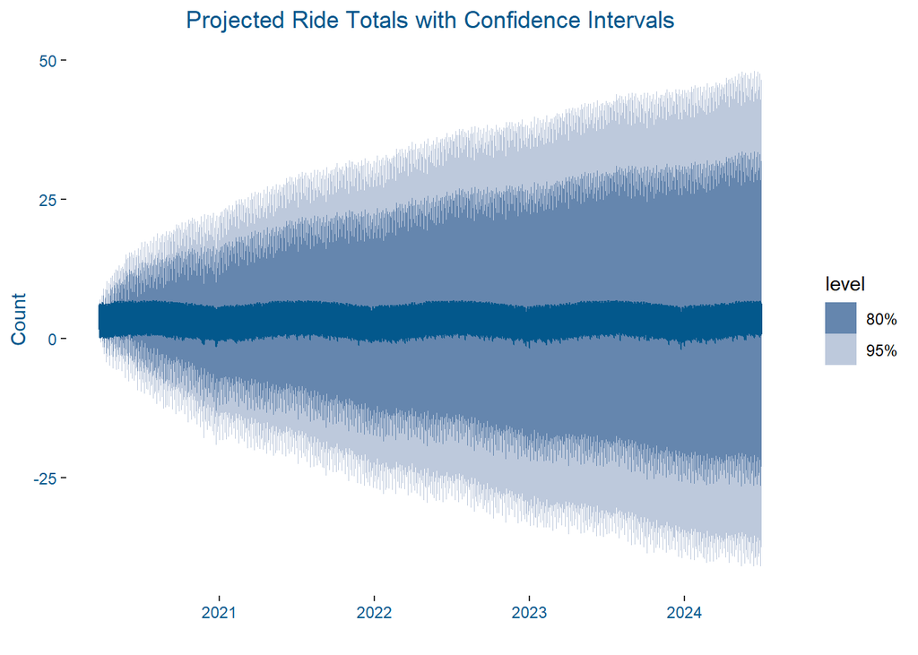

```r
#view the projected ride totals and confidence intervals.
fcst %>% autoplot(color = "#03588C") +
  labs(x = "",
       y = "Count",
       title =  "Projected Ride Totals with Confidence Intervals") +
  theme(plot.title = element_text(hjust = 0.5, color = "#03588C"),
        axis.title = element_text(color = "#03588C"),
        panel.grid = element_blank(),
        panel.background = element_blank(),
        axis.text = element_text(color = "#03588C"))
```

### Comparing the Results

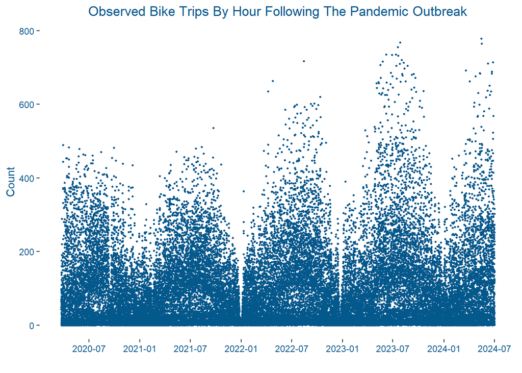

```r
#turn the results into a data.frame and rename
results <- data.frame(fcst$Date_f, fcst$.mean)
names(results) <- c("Date_f","Estimated_total_log")

#join the results to the original observations
compare_df <- counter_postpan %>% left_join(results)

#update the estimated total to be the inverse log
compare_df$Estimated_total <- exp(compare_df$Estimated_total_log)

#map the original pos-pandemic counts and then estimated counts
ggplot(compare_df, aes(x=Date_f, y=Total)) +
  geom_point(size =0.5, colour = "#03588C") +
  scale_x_datetime(breaks = scales::pretty_breaks(n = 12))+
  labs(title = "Observed Bike Trips By Hour Following The Pandemic Outbreak",
       x = "",
       y = "Count") +
  theme(plot.title = element_text(hjust = 0.5, color = "#03588C"),
        axis.title = element_text(color = "#03588C"),
        panel.grid = element_blank(),
        panel.background = element_blank(),
        axis.text = element_text(color = "#03588C"))
```

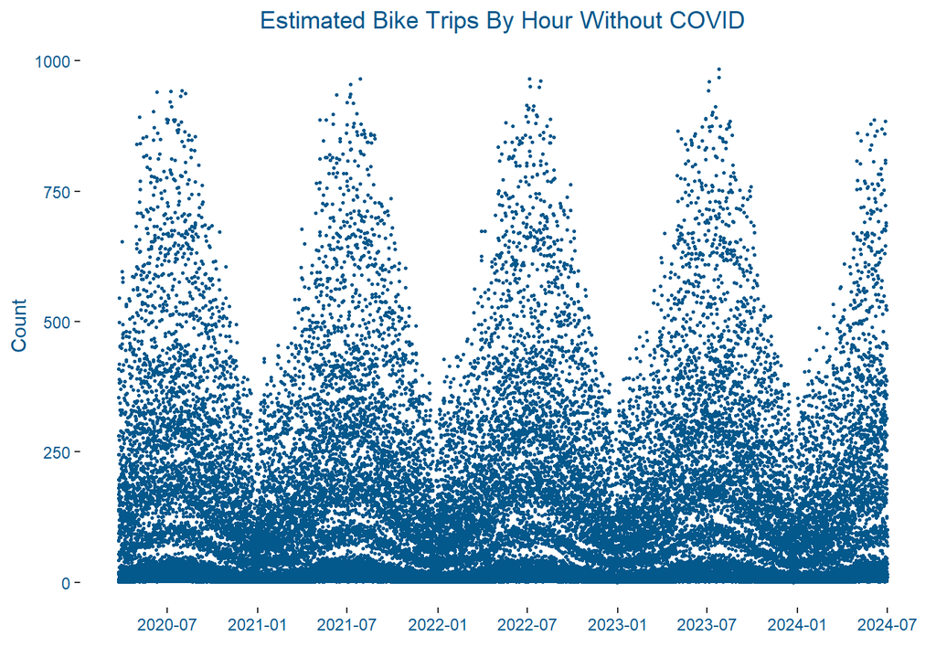

```r
ggplot(compare_df, aes(x=Date_f, y=Estimated_total)) +
  geom_point(size =0.5, colour = "#03588C") +
  scale_x_datetime(breaks = scales::pretty_breaks(n = 12))+
  labs(title = "Estimated Bike Trips By Hour Without COVID",
       x = "",
       y = "Count") +
  theme(plot.title = element_text(hjust = 0.5, color = "#03588C"),
        axis.title = element_text(color = "#03588C"),
        panel.grid = element_blank(),
        panel.background = element_blank(),
        axis.text = element_text(color = "#03588C"))
```

The general shape of the projected values looks reasonable. From here I ran a more narrowed look at a one-week period of the initial lockdown to show the comparison.

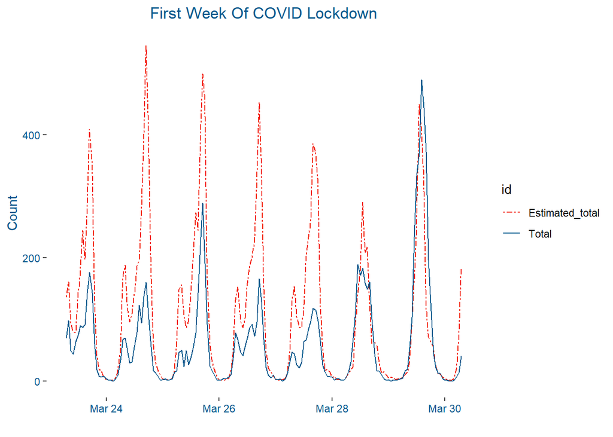

```r
#map the week of March 24, 2020 - March 30, 2020
compare_df %>%
  filter(Date_f <= "2020-03-30") %>%
  select(Date_f, Total, Estimated_total) %>%
  gather("id", "value", 2:3) %>%
ggplot(aes(x=Date_f, y=value, group=id)) +
  geom_line(aes(linetype=id, color= id))+
  scale_linetype_manual(values=c("twodash", "solid"))+
  scale_color_manual(values = c("#F21905","#03588C")) +
  labs(title = "First Week Of COVID Lockdown",
       x = "",
       y = "Count") +
  theme(plot.title = element_text(hjust = 0.5, color = "#03588C"),
        axis.title = element_text(color = "#03588C"),
        panel.grid = element_blank(),
        panel.background = element_blank(),
        axis.text = element_text(color = "#03588C"))
```

My final step is to estimate the number of bike trips that were not taken following the start of the pandemic. While some of these may be a result of direct lockdown orders, other “missed” trips may be a result from changing work habits (increased work from home days) or changes in the population of the surrounding communities.

```r
#Total "missed" bike trips
compare_df <- compare_df %>%
  mutate(Diff = Estimated_total - Total)

sum(compare_df$Diff)
```

```
## [1] 1416060
```

“The only thing we know about the future is that it will be different.” — Peter Drucker

[figure not shown]